# LINEAR MODELS PROJECT REPORT

Aytijhya Saha (BS2002)

In this project, our aim was to take several screenshots that share some common locations and stitch them into a whole map.

In this project, I took several screenshots of satellite images from Google Maps of the area in Bangalore and stitched them into a whole map. However, the code that I used for this, works fine for any and every area on Google Maps.

## Model

Suppose, I have $m$ screenshots and $n$ distinct places to locate on the map.I stored the screenshot number(as ss variable), the name of the place(as place variable) and the co-ordinates of the place with respect to that screenshot. I fitted linear model for predicting the x-ordinate and the y-ordinate separately. For the y-ordinate the model is,
$$y_{ij}=ss_i+place_j+\epsilon_{ij} \text{ where } i=1,\cdots,m; j=1,\cdots n_i \text{ and } \epsilon_{ij}\stackrel{IID}{\sim}N(0,\sigma^2)$$
Note that both the inputs are factor. This is a 2-way ANOVA model. We have only two indices $(i,j)$ as for each type $(i,j)$ we have only one observation. Similarly for the x-ordinate the model is,
$$x_{ij}=ss_i+place_j+\epsilon_{ij} \text{ where } i=1,\cdots,m; j=1,\cdots n_i\text{ and } \epsilon_{ij}\stackrel{IID}{\sim}N(0,\sigma^2)$$

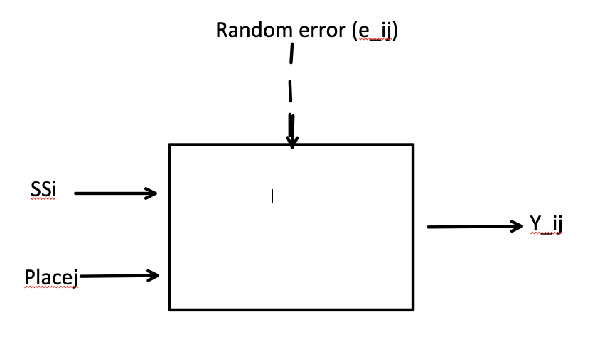

Blackbox diagram

## Design Matrix

Number of columns in design matrix is $m+n$. Number of rows in design matrix = Total number of clicks= $C$ (let). the dimension of the design matrix is =(number of clicks x ( number of distinct place+ number of screenshots)) = $C \times (m+n)$

## Rank of the design matrix

The map formed by the screenshots is connected iff rank(design matrix) = m+n-1.

To understand the idea, consider the screenshots as vertices of a graph and draw an edge between them if they have at least one marked place common. We know if a graph is connected there exists at least (m-1) many edges.

If place(j) is common in $k$ many of the screenshots, there exist at least $k-1$ many edges in the graph. Hence total number of edges in the graph is $\sum_j^n (k(j)-1)=C-n$ where $k(j) =$ number of times place(j) has occurred.

Now, for the columns, if we add all the columns corresponding to place variable we get a vector of 1’s. Similarly adding up all the columns w.r.t. ss variable we get a vector of 1’s. All the ss variables are independent of each other and all the place variables are independent of each other. Hence, column rank of the design matrix = m+n-1.

Combining two cases we get, the map is connected iff rank (design matrix)= m+n-1 Using this I checked for faulty clicks from the users in my software later.

Combining two cases we get, the map is connected iff rank(design matrix)= m+n-1.

Using this I checked for faulty clicks from the users in my software later.

[output not shown]